# Chapter3

Julia ROQUIGNY

2023-11-20

```r
#2 reading the data
alc <- read.csv("data/alc.csv",header = TRUE,sep=",")


#2  structure of the data
str(alc)
```

```
## 'data.frame':    370 obs. of  36 variables:
##  $ school              : chr  "GP" "GP" "GP" "GP" ...
##  $ sex                 : chr  "F" "F" "F" "F" ...
##  $ age                 : int  18 17 15 15 16 16 16 17 15 15 ...
##  $ address             : chr  "U" "U" "U" "U" ...
##  $ famsize             : chr  "GT3" "GT3" "LE3" "GT3" ...
##  $ Pstatus             : chr  "A" "T" "T" "T" ...
##  $ Medu                : int  4 1 1 4 3 4 2 4 3 3 ...
##  $ Fedu                : int  4 1 1 2 3 3 2 4 2 4 ...
##  $ Mjob                : chr  "at_home" "at_home" "at_home" "health" ...
##  $ Fjob                : chr  "teacher" "other" "other" "services" ...
##  $ reason              : chr  "course" "course" "other" "home" ...
##  $ guardian            : chr  "mother" "father" "mother" "mother" ...
##  $ traveltime          : int  2 1 1 1 1 1 1 2 1 1 ...
##  $ studytime           : int  2 2 2 3 2 2 2 2 2 2 ...
```

[output cut: 22 more lines]

```r
colnames(alc)
```

```
##  [1] "school"               "sex"                  "age"
##  [4] "address"              "famsize"              "Pstatus"
##  [7] "Medu"                 "Fedu"                 "Mjob"
## [10] "Fjob"                 "reason"               "guardian"
## [13] "traveltime"           "studytime"            "schoolsup"
## [16] "famsup"               "activities"           "nursery"
## [19] "higher"               "internet"             "romantic"
## [22] "famrel"               "freetime"             "goout"
## [25] "Dalc"                 "Walc"                 "health"
## [28] "failures"             "paid"                 "absences"
## [31] "G1"                   "G2"                   "G3"
## [34] "alc_use"              "join_column_only_use" "high_use"
```

The data consist of 370 observations of 36 variables.

#3 hypothesis I choose the variables “school”,sex”,“address”, “Pstatus” to investigate whether the school, the gender, the home address type, the parent’s cohabitation status affect the low/high alcohol consumption. I hypothesize that man, people studying in one of the two school, living in urban area, with parents apart, drink more alcohol than women, people studying in the other school, living in rural areas, with parents together, respectively.

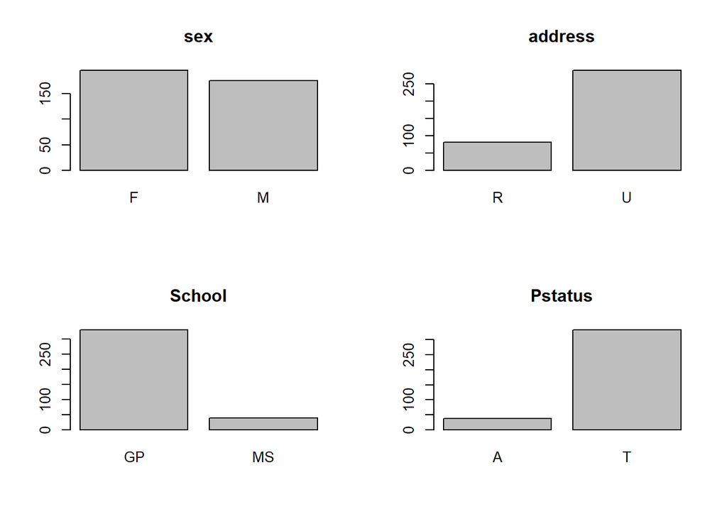

```r
#Numerically and graphically explore the distributions of your chosen variables and their relationships with alcohol consumption

library(dplyr); library(ggplot2)
#BARPLOTS
par(mfrow = c(2,2))

barplot(table(alc$sex),main ="sex")
barplot(table(alc$address),main ="address")
barplot(table(alc$school),main ="School")
barplot(table(alc$Pstatus),main ="Pstatus")
```

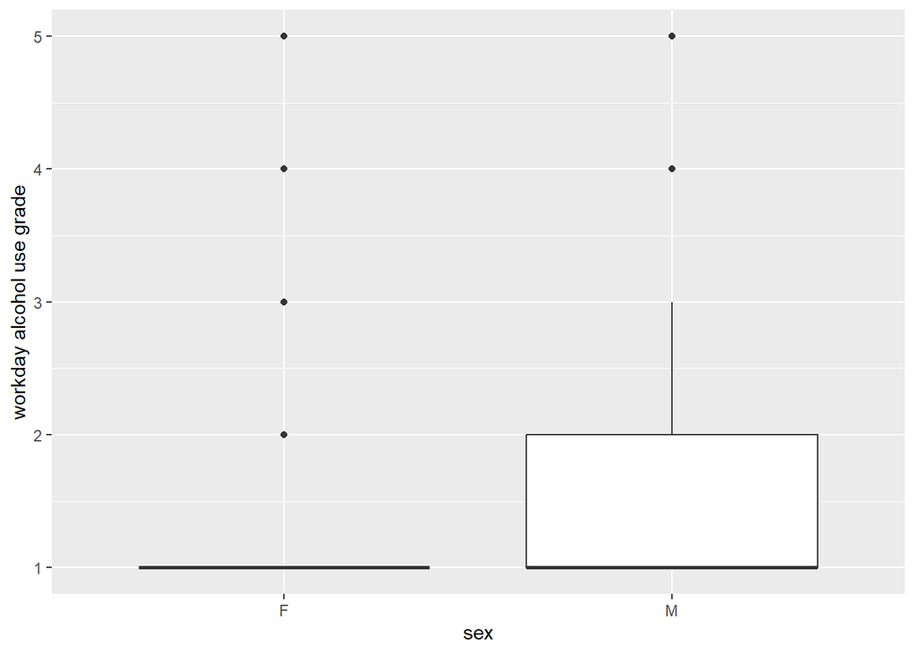

```r
# workday & weekend alcohol use  by sex
library(ggplot2)
g1 <- ggplot(alc, aes(x = sex, y = Dalc))
g2 <- ggplot(alc, aes(x = sex, y = Walc))
g1 + geom_boxplot() + ylab("workday alcohol use grade")
```

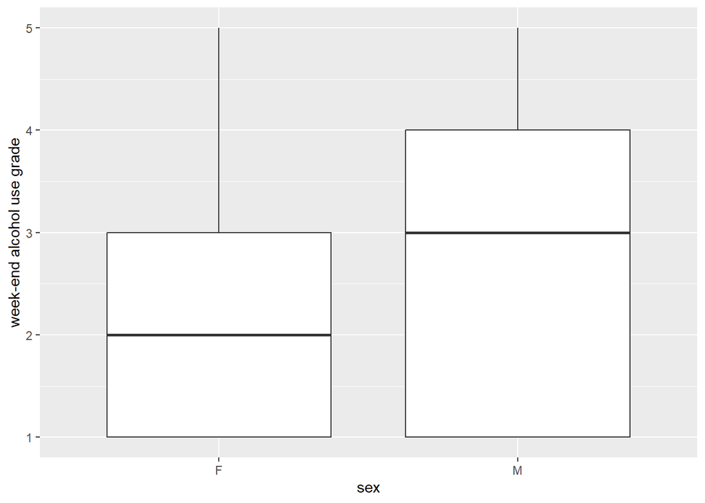

```r
g2 + geom_boxplot() + ylab("week-end alcohol use grade")
```

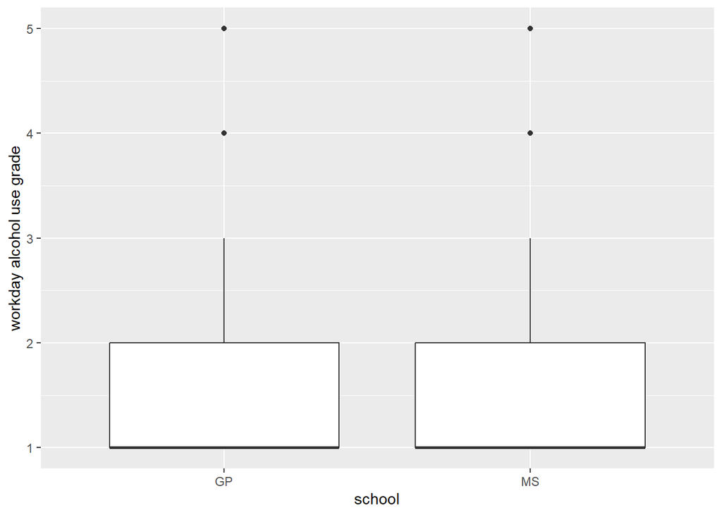

```r
# workday & weekend  alcohol use  by school
g3<- ggplot(data = alc, aes(x = school,y=Dalc))
g4<- ggplot(data = alc, aes(x = school,y=Walc))

g3 + geom_boxplot() + ylab("workday alcohol use grade")
```

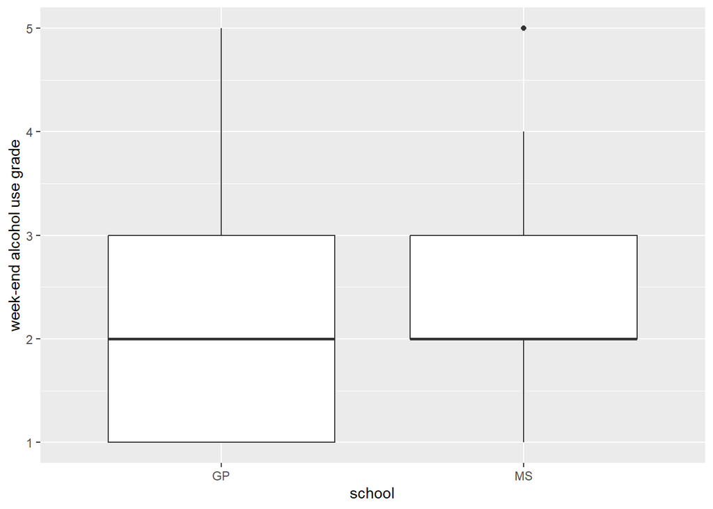

```r
g4 + geom_boxplot() + ylab("week-end alcohol use grade")
```

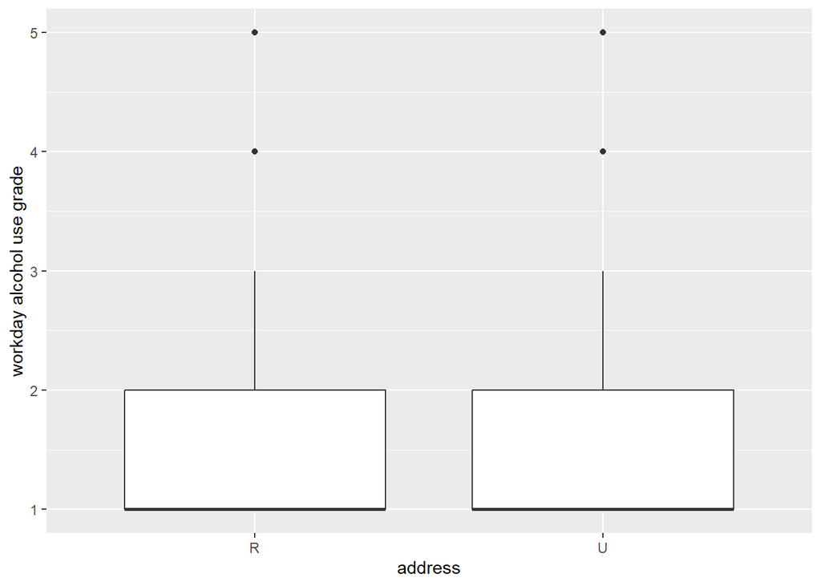

```r
# workday & weekend  alcohol use  by school
g5<- ggplot(data = alc, aes(x = address,y=Dalc))
g6<- ggplot(data = alc, aes(x = address,y=Walc))
g5 + geom_boxplot() + ylab("workday alcohol use grade")
```